# Full_Code_AIML_USL_Project_CreditCardCustomerSegmentation

## Problem Statement

### Context

AllLife Bank wants to focus on its credit card customer base in the next financial year. They have been advised by their marketing research team, that the penetration in the market can be improved. Based on this input, the Marketing team proposes to run personalized campaigns to target new customers as well as upsell to existing customers. Another insight from the market research was that the customers perceive the support services of the back poorly. Based on this, the Operations team wants to upgrade the service delivery model, to ensure that customer queries are resolved faster. Head of Marketing and Head of Delivery both decide to reach out to the Data Science team for help

### Objective

To identify different segments in the existing customer, based on their spending patterns as well as past interaction with the bank, using clustering algorithms, and provide recommendations to the bank on how to better market to and service these customers.

### Data Description

The data provided is of various customers of a bank and their financial attributes like credit limit, the total number of credit cards the customer has, and different channels through which customers have contacted the bank for any queries (including visiting the bank, online and through a call center).

**Data Dictionary**

- Sl_No: Primary key of the records
- Customer Key: Customer identification number
- Average Credit Limit: Average credit limit of each customer for all credit cards
- Total credit cards: Total number of credit cards possessed by the customer
- Total visits bank: Total number of Visits that customer made (yearly) personally to the bank
- Total visits online: Total number of visits or online logins made by the customer (yearly)
- Total calls made: Total number of calls made by the customer to the bank or its customer service department (yearly)

## Importing necessary libraries and data

```python
# this will help in making the Python code more structured automatically (good coding practice)
# %load_ext nb_black

# Libraries to help with reading and manipulating data
import pandas as pd
import numpy as np

# libaries to help with data visualization
import matplotlib.pyplot as plt
import seaborn as sns

# Removes the limit for the number of displayed columns
pd.set_option("display.max_columns", None)
# Sets the limit for the number of displayed rows
pd.set_option("display.max_rows", 200)

# to scale the data using z-score
from sklearn.preprocessing import StandardScaler

# to compute distances
from scipy.spatial.distance import cdist, pdist

# to perform k-means clustering and compute silhouette scores
from sklearn.cluster import KMeans
from sklearn.metrics import silhouette_score

# to visualize the elbow curve and silhouette scores
from yellowbrick.cluster import KElbowVisualizer, SilhouetteVisualizer

# to perform hierarchical clustering, compute cophenetic correlation, and create dendrograms
from sklearn.cluster import AgglomerativeClustering
from scipy.cluster.hierarchy import dendrogram, linkage, cophenet

# to suppress warnings
import warnings

warnings.filterwarnings("ignore")
```

```python
customer_data = pd.read_excel('Credit+Card+Customer+Data.xlsx')## Complete the code to import the data
```

## Data Overview

- Observations
- Sanity checks

```python
rows = customer_data.shape[0]
cols = customer_data.shape[1]


print(f"There are {rows} rows and {cols} columns.") ## Complete the code to get the shape of data
```

```
There are 660 rows and 7 columns.
```

```python
customer_data.head()
```

|  | Sl_No | Customer Key | Avg_Credit_Limit | Total_Credit_Cards | Total_visits_bank | Total_visits_online | Total_calls_made |
| --- | --- | --- | --- | --- | --- | --- | --- |
| 0 | 1 | 87073 | 100000 | 2 | 1 | 1 | 0 |
| 1 | 2 | 38414 | 50000 | 3 | 0 | 10 | 9 |
| 2 | 3 | 17341 | 50000 | 7 | 1 | 3 | 4 |
| 3 | 4 | 40496 | 30000 | 5 | 1 | 1 | 4 |
| 4 | 5 | 47437 | 100000 | 6 | 0 | 12 | 3 |

```python
customer_data_copy1 = customer_data.copy()
```

```python
# fixing column names
customer_data_copy1.columns = [c.replace(" ", "_") for c in customer_data_copy1.columns]
```

```python
customer_data_copy1.head()
```

|  | Sl_No | Customer_Key | Avg_Credit_Limit | Total_Credit_Cards | Total_visits_bank | Total_visits_online | Total_calls_made |
| --- | --- | --- | --- | --- | --- | --- | --- |
| 0 | 1 | 87073 | 100000 | 2 | 1 | 1 | 0 |
| 1 | 2 | 38414 | 50000 | 3 | 0 | 10 | 9 |
| 2 | 3 | 17341 | 50000 | 7 | 1 | 3 | 4 |
| 3 | 4 | 40496 | 30000 | 5 | 1 | 1 | 4 |
| 4 | 5 | 47437 | 100000 | 6 | 0 | 12 | 3 |

```python
customer_data_copy1.info()
```

```
<class 'pandas.core.frame.DataFrame'>
RangeIndex: 660 entries, 0 to 659
Data columns (total 7 columns):
 #   Column               Non-Null Count  Dtype
---  ------               --------------  -----
 0   Sl_No                660 non-null    int64
 1   Customer_Key         660 non-null    int64
 2   Avg_Credit_Limit     660 non-null    int64
 3   Total_Credit_Cards   660 non-null    int64
 4   Total_visits_bank    660 non-null    int64
 5   Total_visits_online  660 non-null    int64
 6   Total_calls_made     660 non-null    int64
dtypes: int64(7)
memory usage: 36.2 KB
```

```python
customer_data_copy1.isnull().sum()
```

```
Sl_No                  0
Customer_Key           0
Avg_Credit_Limit       0
Total_Credit_Cards     0
Total_visits_bank      0
Total_visits_online    0
Total_calls_made       0
dtype: int64
```

```python
customer_data_copy1.nunique()
```

```
Sl_No                  660
Customer_Key           655
Avg_Credit_Limit       110
Total_Credit_Cards      10
Total_visits_bank        6
Total_visits_online     16
Total_calls_made        11
dtype: int64
```

#### Duplicate values

```python
# getting the count for each unique value in Customer_Key
data_grouped = customer_data_copy1.groupby("Customer_Key").count()

for i in data_grouped.loc[data_grouped.Sl_No >= 2].index:
    display(customer_data_copy1.loc[customer_data_copy1.Customer_Key == i])
```

|  | Sl_No | Customer_Key | Avg_Credit_Limit | Total_Credit_Cards | Total_visits_bank | Total_visits_online | Total_calls_made |
| --- | --- | --- | --- | --- | --- | --- | --- |
| 48 | 49 | 37252 | 6000 | 4 | 0 | 2 | 8 |
| 432 | 433 | 37252 | 59000 | 6 | 2 | 1 | 2 |

|  | Sl_No | Customer_Key | Avg_Credit_Limit | Total_Credit_Cards | Total_visits_bank | Total_visits_online | Total_calls_made |
| --- | --- | --- | --- | --- | --- | --- | --- |
| 4 | 5 | 47437 | 100000 | 6 | 0 | 12 | 3 |
| 332 | 333 | 47437 | 17000 | 7 | 3 | 1 | 0 |

|  | Sl_No | Customer_Key | Avg_Credit_Limit | Total_Credit_Cards | Total_visits_bank | Total_visits_online | Total_calls_made |
| --- | --- | --- | --- | --- | --- | --- | --- |
| 411 | 412 | 50706 | 44000 | 4 | 5 | 0 | 2 |
| 541 | 542 | 50706 | 60000 | 7 | 5 | 2 | 2 |

|  | Sl_No | Customer_Key | Avg_Credit_Limit | Total_Credit_Cards | Total_visits_bank | Total_visits_online | Total_calls_made |
| --- | --- | --- | --- | --- | --- | --- | --- |
| 391 | 392 | 96929 | 13000 | 4 | 5 | 0 | 0 |
| 398 | 399 | 96929 | 67000 | 6 | 2 | 2 | 2 |

|  | Sl_No | Customer_Key | Avg_Credit_Limit | Total_Credit_Cards | Total_visits_bank | Total_visits_online | Total_calls_made |
| --- | --- | --- | --- | --- | --- | --- | --- |
| 104 | 105 | 97935 | 17000 | 2 | 1 | 2 | 10 |
| 632 | 633 | 97935 | 187000 | 7 | 1 | 7 | 0 |

#### Observations

- There are some customers in the dataset with duplicate data

```python
customer_data_copy2 = customer_data_copy1.copy()
```

```python
#Check : drop sl_no and customer_key

customer_data_copy1.drop(columns=["Sl_No"], inplace=True) # complete the code to drop the columns
customer_data_copy1.drop(columns=["Customer_Key"], inplace=True) # complete the code to drop the columns
```

```python
customer_data_copy1.describe().T
```

|  | count | mean | std | min | 25% | 50% | 75% | max |
| --- | --- | --- | --- | --- | --- | --- | --- | --- |
| Avg_Credit_Limit | 660.0 | 34574.242424 | 37625.487804 | 3000.0 | 10000.0 | 18000.0 | 48000.0 | 200000.0 |
| Total_Credit_Cards | 660.0 | 4.706061 | 2.167835 | 1.0 | 3.0 | 5.0 | 6.0 | 10.0 |
| Total_visits_bank | 660.0 | 2.403030 | 1.631813 | 0.0 | 1.0 | 2.0 | 4.0 | 5.0 |
| Total_visits_online | 660.0 | 2.606061 | 2.935724 | 0.0 | 1.0 | 2.0 | 4.0 | 15.0 |
| Total_calls_made | 660.0 | 3.583333 | 2.865317 | 0.0 | 1.0 | 3.0 | 5.0 | 10.0 |

#### Observations

- There are some customers in the dataset with duplicate data

## Exploratory Data Analysis (EDA)

- Duplicate value check
- Missing value treatment
- Outlier check
- Feature engineering (if needed)
- Any other preprocessing steps (if needed)
- EDA is an important part of any project involving data.
- It is important to investigate and understand the data better before building a model with it.
- A few questions have been mentioned below which will help you approach the analysis in the right manner and generate insights from the data.
- A thorough analysis of the data, in addition to the questions mentioned below, should be done.

### Questions

1. How is the distrubution of average credit limit of customer?
2. What percenatage of the customers have never made a service-related call to the bank?
3. What percentage of customers have never logged in to the online portal?
4. How many customers have never visited bank?
5. How are the different variables correlated with each other?

#### Functions

```python
# function to plot a boxplot and a histogram along the same scale.


def histogram_boxplot(data, feature, figsize=(15, 6), kde=False, bins=None):
    """
    Boxplot and histogram combined

    data: dataframe
    feature: dataframe column
    figsize: size of figure (default (12,7))
    kde: whether to the show density curve (default False)
    bins: number of bins for histogram (default None)
    """
    f2, (ax_box2, ax_hist2) = plt.subplots(
        nrows=2,  # Number of rows of the subplot grid= 2
        sharex=True,  # x-axis will be shared among all subplots
        gridspec_kw={"height_ratios": (0.25, 0.75)},
        figsize=figsize,
    )  # creating the 2 subplots
    sns.boxplot(
        data=data, x=feature, ax=ax_box2, showmeans=True, color="violet"
    )  # boxplot will be created and a star will indicate the mean value of the column
    sns.histplot(
        data=data, x=feature, kde=kde, ax=ax_hist2, bins=bins, palette="winter"
    ) if bins else sns.histplot(
        data=data, x=feature, kde=kde, ax=ax_hist2
    )  # For histogram
    ax_hist2.axvline(
        data[feature].mean(), color="green", linestyle="--"
    )  # Add mean to the histogram
    ax_hist2.axvline(
        data[feature].median(), color="black", linestyle="-"
    )  # Add median to the histogram
```

```python
# function to create labeled barplots


def labeled_barplot(data, feature, perc=False, n=None):
    """
    Barplot with percentage at the top

    data: dataframe
    feature: dataframe column
    perc: whether to display percentages instead of count (default is False)
    n: displays the top n category levels (default is None, i.e., display all levels)
    """

    total = len(data[feature])  # length of the column
    count = data[feature].nunique()
    if n is None:
        plt.figure(figsize=(count + 1, 5))
    else:
        plt.figure(figsize=(n + 1, 5))

    plt.xticks(rotation=90, fontsize=15)
    ax = sns.countplot(
        data=data,
        x=feature,
        palette="Paired",
        order=data[feature].value_counts().index[:n].sort_values(),
    )

    for p in ax.patches:
        if perc == True:
            label = "{:.1f}%".format(
                100 * p.get_height() / total
            )  # percentage of each class of the category
        else:
            label = p.get_height()  # count of each level of the category

        x = p.get_x() + p.get_width() / 2  # width of the plot
        y = p.get_height()  # height of the plot

        ax.annotate(
            label,
            (x, y),
            ha="center",
            va="center",
            size=12,
            xytext=(0, 5),
            textcoords="offset points",
        )  # annotate the percentage

    plt.show()  # show the plot
```

### Univariate analysis

#### Avg_Credit_Limit

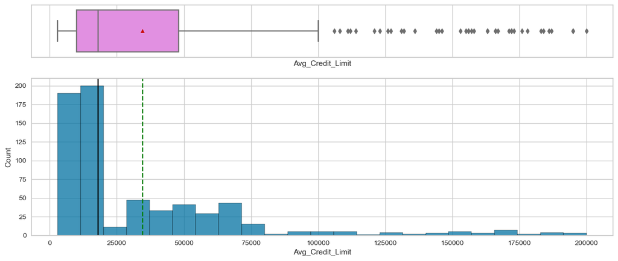

```python
histogram_boxplot(customer_data_copy1, 'Avg_Credit_Limit')
```

#### Total_Credit_Cards

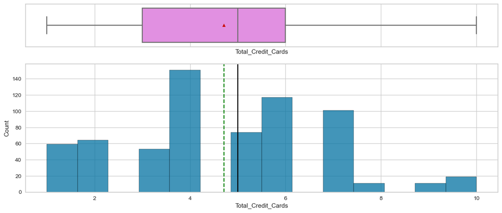

```python
histogram_boxplot(customer_data_copy1, 'Total_Credit_Cards')
```

#### Observations

- Average number of cc a customer has is between 4 and 6

#### Total_visits_bank

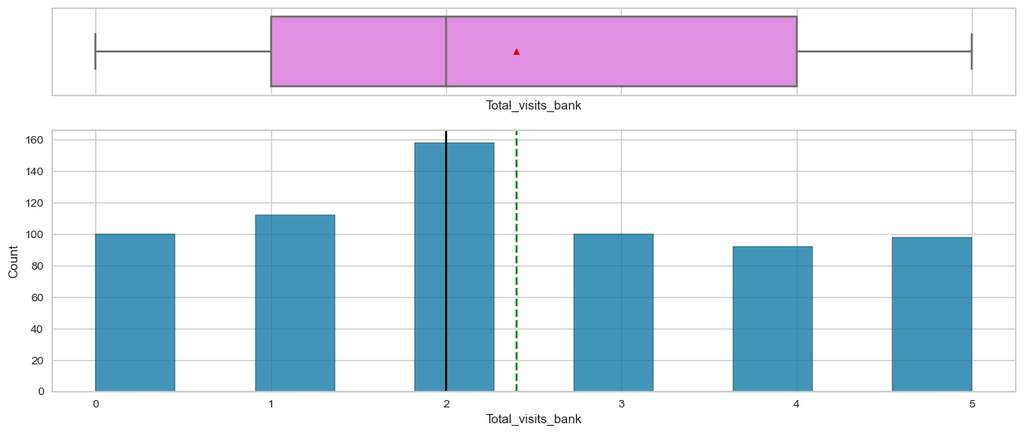

```python
histogram_boxplot(customer_data_copy1, 'Total_visits_bank')
```

#### Observations

- Number of visits a customer has made visit to the bank is 2 or 3

#### Total_visits_online

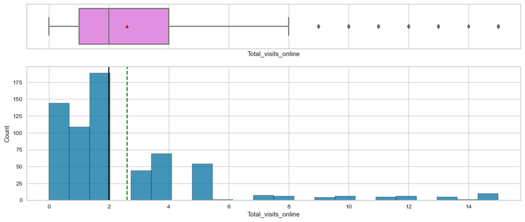

```python
histogram_boxplot(customer_data_copy1, 'Total_visits_online')
```

#### Total_calls_made

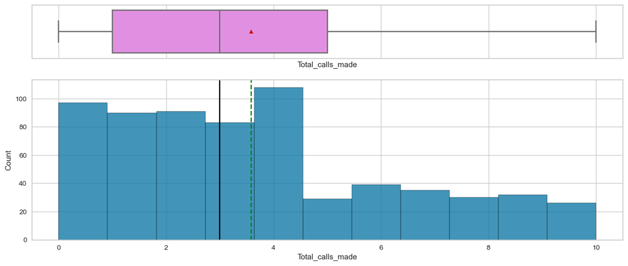

```python
histogram_boxplot(customer_data_copy1, 'Total_calls_made')
```

#### Observations

- Total number of calls made yearly by the customer to the bank is low. (around 3).

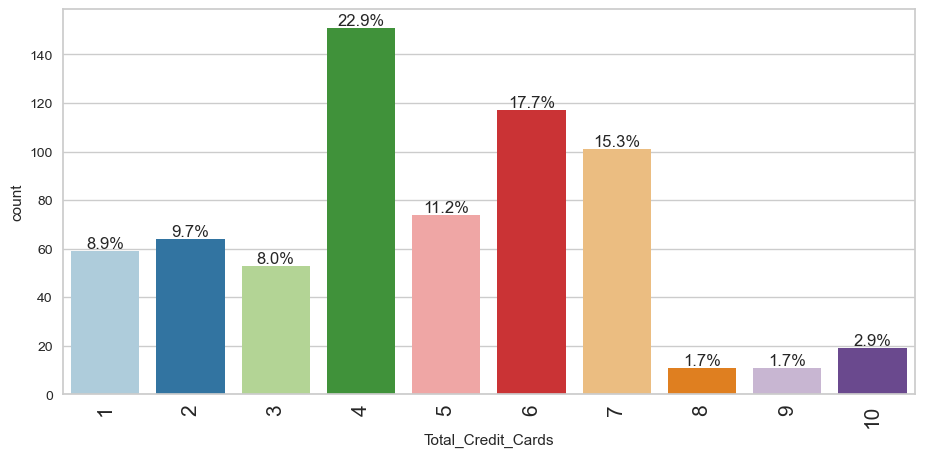

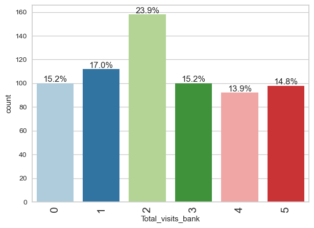

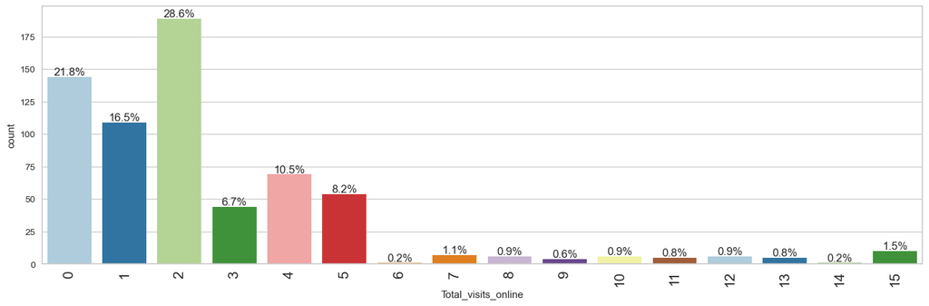

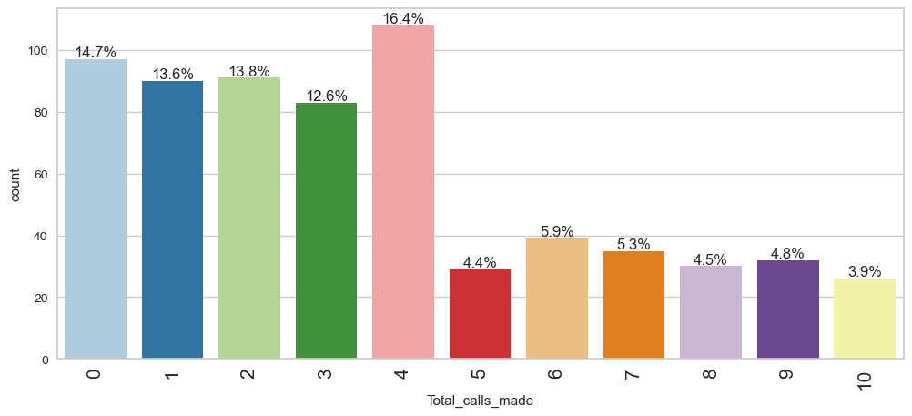

```python
for col in customer_data_copy1.columns.tolist()[1:]:
    labeled_barplot(customer_data_copy1, col, perc=True)
```

#### Observations

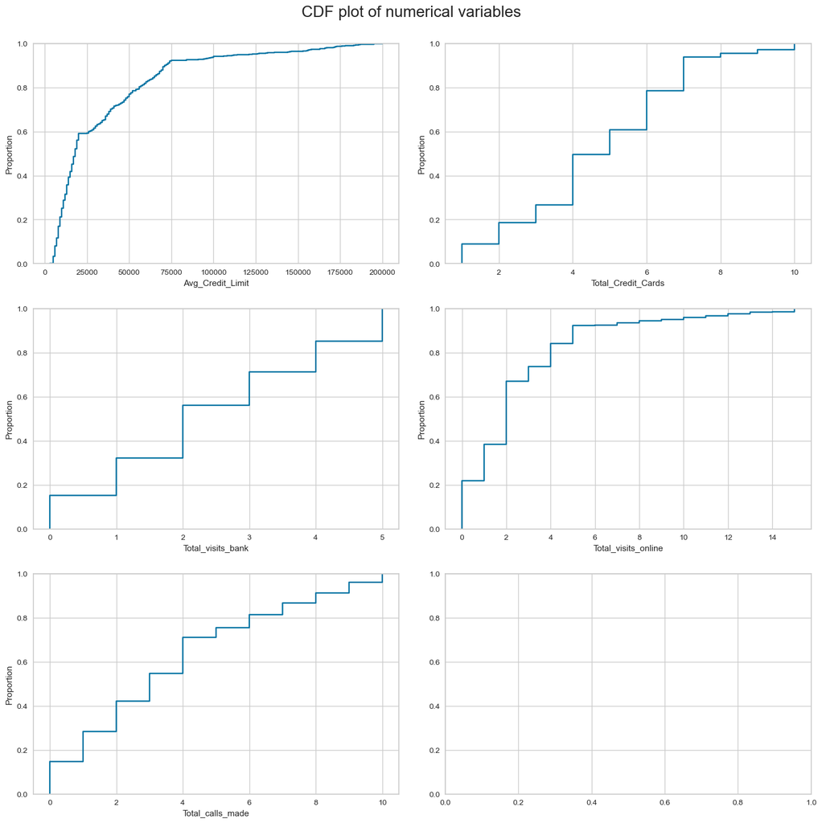

```python
fig, axes = plt.subplots(3, 2, figsize=(15, 15))
fig.suptitle("CDF plot of numerical variables", fontsize=20)

counter = 0

for ii in range(3):
    sns.ecdfplot(data=customer_data_copy1, ax=axes[ii][0], x=customer_data_copy1.columns.tolist()[counter])
    counter = counter + 1
    if counter != 5:
        sns.ecdfplot(data=customer_data_copy1, ax=axes[ii][1], x=customer_data_copy1.columns.tolist()[counter])
        counter = counter + 1
    else:
        pass

fig.tight_layout(pad=2.0)
```

### Bivariate Analysis

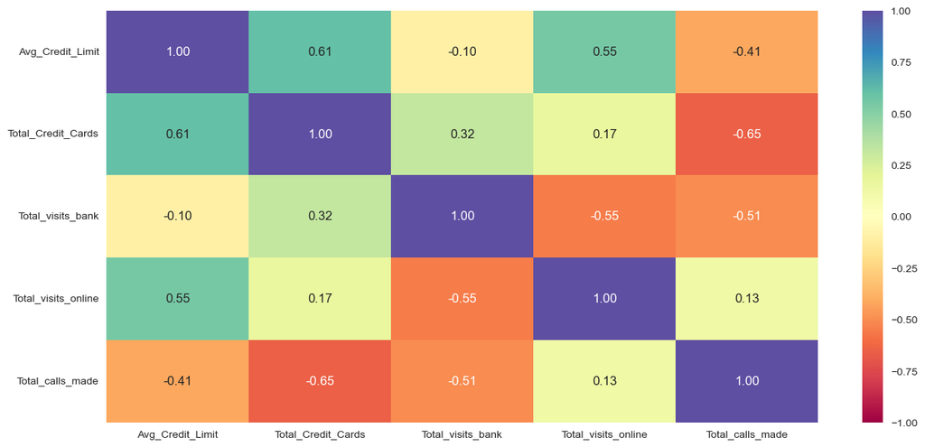

```python
plt.figure(figsize=(15, 7))
sns.heatmap(customer_data_copy1.corr(), annot=True, vmin=-1, vmax=1, fmt=".2f", cmap="Spectral")
plt.show()
```

#### Observations

- High correlation between Total_Credit_Cards and Avg_Credit_Limit. Holds true that customers tend to use more cc and hence more cards
- Also high correlation between Total_visits_online and Avg_Credit_Limit.
- We also see negative correlation between Total_visits_bank and Total_visits_online.

#### Creating a PairPlot between the data columns

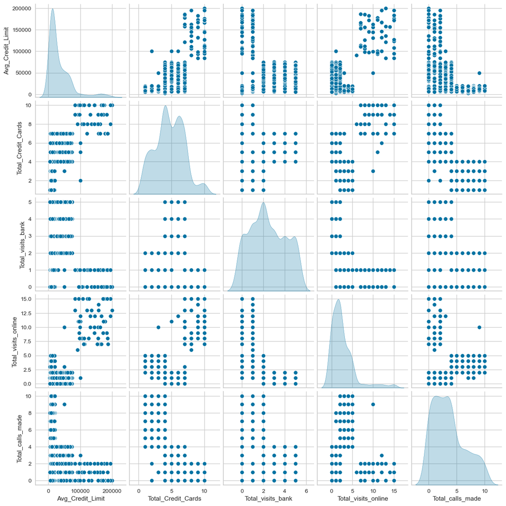

```python
sns.pairplot(data=customer_data_copy1, diag_kind="kde")
plt.show()
```

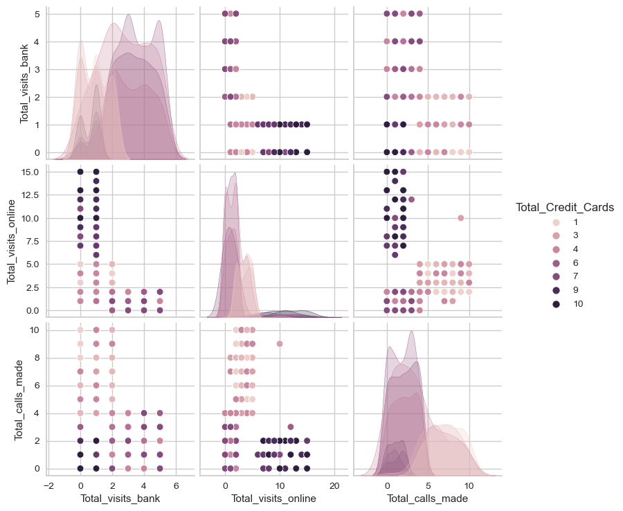

```python
sns.pairplot(
    data=customer_data_copy1[
        [
            "Total_visits_bank",
            "Total_visits_online",
            "Total_calls_made",
            "Total_Credit_Cards",
        ]
    ],
    hue="Total_Credit_Cards",
)

plt.show()
```

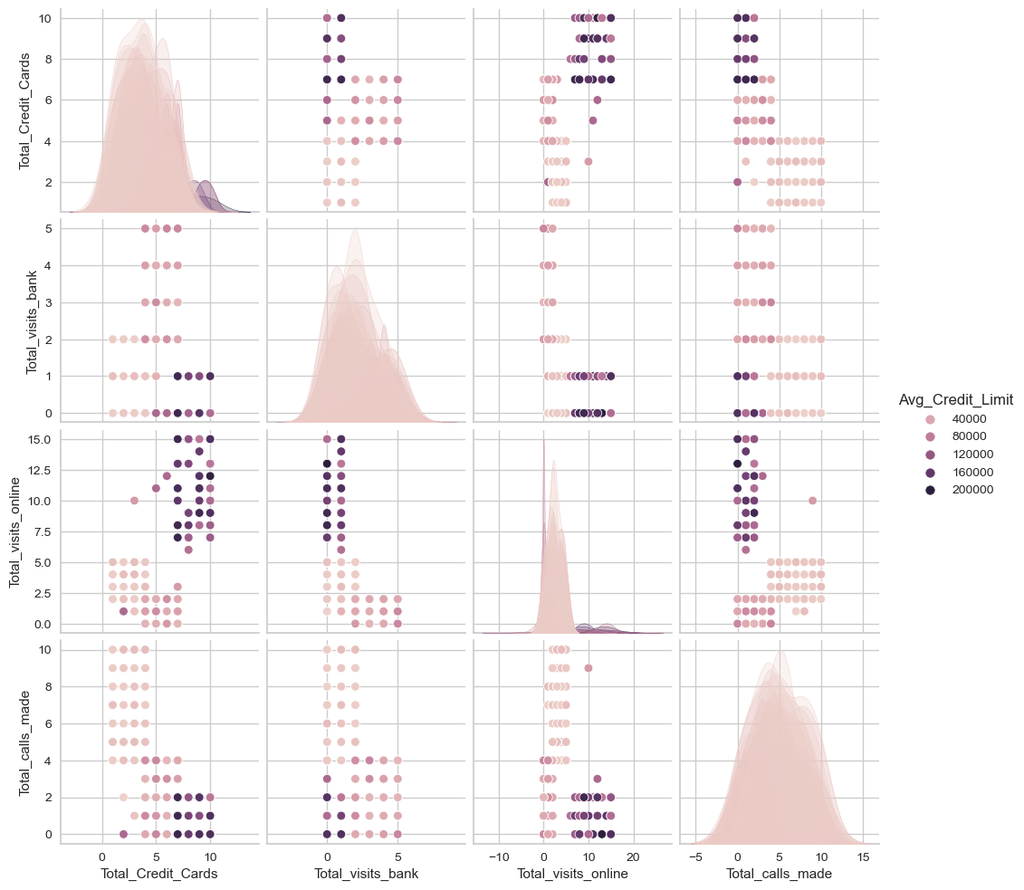

```python
sns.pairplot(customer_data_copy1, hue='Avg_Credit_Limit');
```

#### Observations

We can see the relation between the total number of cc cards the customer has and theri behavior based on:

- Total_visits_online: Less than 10 visits for users with less than 6 credit cards. More cards more visits.
- Total_visits_bank: Users with 10 cc tens to make less vistis to the bank. Theier are users with 6 or less cards that make visits to the bank.
- Total_calls_made: Less cars more calls. More cards less calls.

#### Data in 3D

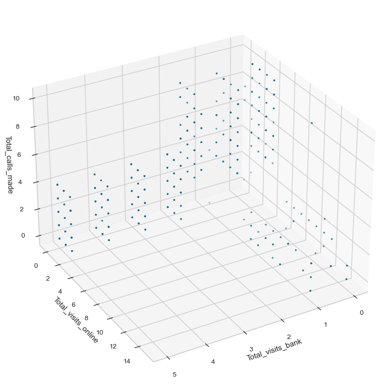

```python
from mpl_toolkits.mplot3d import Axes3D

fig = plt.figure(figsize=(10, 10))
ax = plt.axes(projection="3d")

x = customer_data_copy1["Total_visits_bank"]
y = customer_data_copy1["Total_visits_online"]
z = customer_data_copy1["Total_calls_made"]


ax.scatter(x, y, z, marker=".")
ax.set_xlabel("Total_visits_bank")
ax.set_ylabel("Total_visits_online")
ax.set_zlabel("Total_calls_made")
ax.view_init(azim=60)
plt.show()
```

## Data Preprocessing

#### Outlier Detection

Finding outliers in the data using z-score with a threshold of 3.

```python
threshold = 3 # wite the value of the threshold
outlier = {}
for col in customer_data_copy1.columns:
    i = customer_data_copy1[col]
    mean = np.mean(customer_data_copy1[col])
    std = np.std(customer_data_copy1[col])
    list1 = []
    for v in i:
        z = (v - mean) / std
        if z > threshold:
            list1.append(v)
    list1.sort()
    outlier[i.name] = list1

print("The following are the outliers in the data:")
for key, value in outlier.items():
    print("\n", key, ":", value)
```

```
The following are the outliers in the data:

 Avg_Credit_Limit : [153000, 155000, 156000, 156000, 157000, 158000, 163000, 163000, 166000, 166000, 167000, 171000, 172000, 172000, 173000, 176000, 178000, 183000, 184000, 186000, 187000, 195000, 195000, 200000]

 Total_Credit_Cards : []

 Total_visits_bank : []

 Total_visits_online : [12, 12, 12, 12, 12, 12, 13, 13, 13, 13, 13, 14, 15, 15, 15, 15, 15, 15, 15, 15, 15, 15]

 Total_calls_made : []
```

```python
numerical_col = customer_data_copy1.select_dtypes(include=np.number).columns.tolist()
numerical_col
```

```
['Avg_Credit_Limit',
 'Total_Credit_Cards',
 'Total_visits_bank',
 'Total_visits_online',
 'Total_calls_made']
```

#### Observations

- These are numberic outliers for some of the users for 'Avg_Credit_Limit ' and 'Total_visits_online'
- Though outliers, they are correct as the avg credit limit could belong to high worth individuals and well as the total online visits shows some users with more online activity than others.

#### Scaling

```python
# scaling the data before clustering
scaler = StandardScaler()
customer_data_copy2 = customer_data_copy1.copy()
subset = customer_data_copy2
subset_scaled = scaler.fit_transform(subset)
```

```python
# creating a dataframe of the scaled data
subset_scaled_df = pd.DataFrame(subset_scaled, columns=subset.columns)
```

```python
subset_scaled_df.head()
```

|  | Avg_Credit_Limit | Total_Credit_Cards | Total_visits_bank | Total_visits_online | Total_calls_made |
| --- | --- | --- | --- | --- | --- |
| 0 | 1.740187 | -1.249225 | -0.860451 | -0.547490 | -1.251537 |
| 1 | 0.410293 | -0.787585 | -1.473731 | 2.520519 | 1.891859 |
| 2 | 0.410293 | 1.058973 | -0.860451 | 0.134290 | 0.145528 |
| 3 | -0.121665 | 0.135694 | -0.860451 | -0.547490 | 0.145528 |
| 4 | 1.740187 | 0.597334 | -1.473731 | 3.202298 | -0.203739 |

## K-means Clustering

#### Checking the optimal number of clusters

#### (a) Elbow Plot

```python
k_means_df = subset_scaled_df.copy()
```

```
Number of Clusters: 2 	Average Distortion: 2040.9898164784947
Number of Clusters: 3 	Average Distortion: 933.0437490000531
Number of Clusters: 4 	Average Distortion: 780.773689555177
Number of Clusters: 5 	Average Distortion: 704.4759188657513
Number of Clusters: 6 	Average Distortion: 642.4285451423211
Number of Clusters: 7 	Average Distortion: 600.2238778375963
Number of Clusters: 8 	Average Distortion: 574.4418958177622
Number of Clusters: 9 	Average Distortion: 538.8269188945013
Number of Clusters: 10 	Average Distortion: 509.16313788912544
```

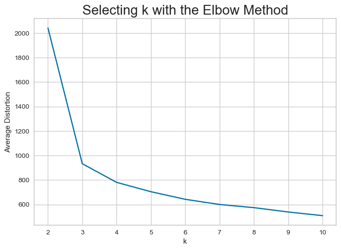

```python
clusters = range(2, 11)
meanDistortions = []

for k in clusters:
    model = KMeans(n_clusters=k, random_state=1)
    model.fit(subset_scaled_df)
    prediction = model.predict(k_means_df)
    distortion = sum(
        np.min(cdist(k_means_df, model.cluster_centers_, "euclidean"), axis=1) ** 2)

    meanDistortions.append(distortion)

    print("Number of Clusters:", k, "\tAverage Distortion:", distortion)

plt.plot(clusters, meanDistortions, "bx-")
plt.xlabel("k")
plt.ylabel("Average Distortion")
plt.title("Selecting k with the Elbow Method", fontsize=20)
plt.show()
```

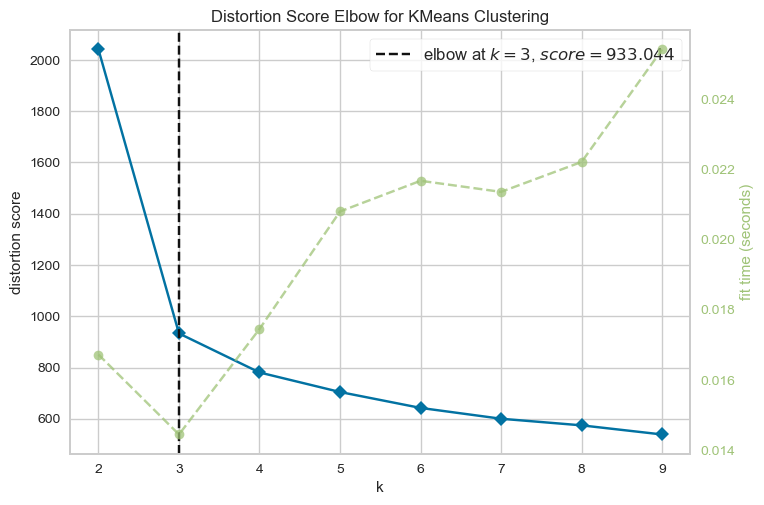

```python
model = KMeans(random_state=1)
visualizer = KElbowVisualizer(model, k=(2, 10), timings=True)
visualizer.fit(k_means_df)  # fit the data to the visualizer
visualizer.show()  # finalize and render figure
```

#### OBSERVATIONS

- From the above K-Mean Elbow visualizer, we can see the distortion score is the best at K=3 with distortion of 933

#### (b) silhouette scores

```python
sil_score = []
cluster_list = range(2, 10)
for n_clusters in cluster_list:
    clusterer = KMeans(n_clusters=n_clusters, random_state=1)
    preds = clusterer.fit_predict((subset_scaled_df))
    score = silhouette_score(k_means_df, preds)
    sil_score.append(score)
    print("For n_clusters = {}, the silhouette score is {})".format(n_clusters, score))
```

```
For n_clusters = 2, the silhouette score is 0.41842496663230416)
For n_clusters = 3, the silhouette score is 0.5157182558882754)
For n_clusters = 4, the silhouette score is 0.3556670619377371)
For n_clusters = 5, the silhouette score is 0.2717470361094591)
For n_clusters = 6, the silhouette score is 0.2559067652985087)
For n_clusters = 7, the silhouette score is 0.2479864465613871)
For n_clusters = 8, the silhouette score is 0.24142401447729542)
For n_clusters = 9, the silhouette score is 0.21846450507663692)
```

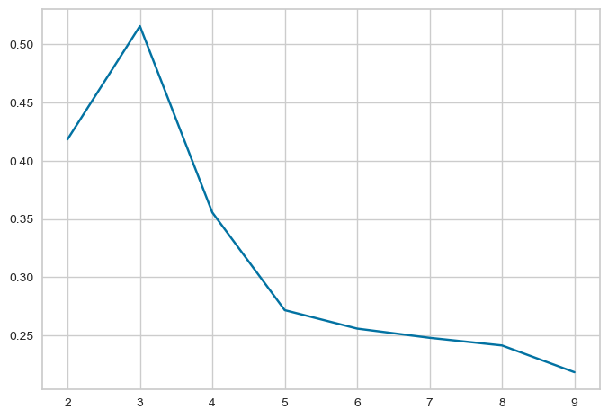

```python
plt.plot(cluster_list, sil_score)
plt.show()
```

#### OBSERVATIONS

Highest silhoutte score is at 3 as well

#### Let's visualize the silhouette scores for different number of clusters

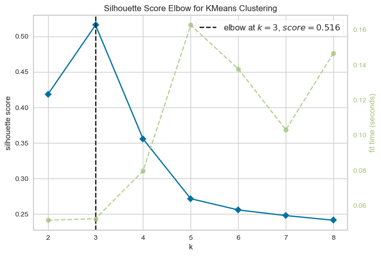

```python
model = KMeans(random_state=1)
visualizer = KElbowVisualizer(model, k=(2, 9), metric="silhouette", timings=True) ## Complete the code to visualize the silhouette scores for certain number of clusters
visualizer.fit(k_means_df)  # fit the data to the visualizer
visualizer.show()  # finalize and render figure
```

#### OBSERVATIONS

- From the above Silhouette method, we can identify that the ideal number of clusters should be 3
- at K=3, we get the value closest to 1, that is around 0.52

#### (c) Using SilhouetteVisualizer to justify the Silhouette score

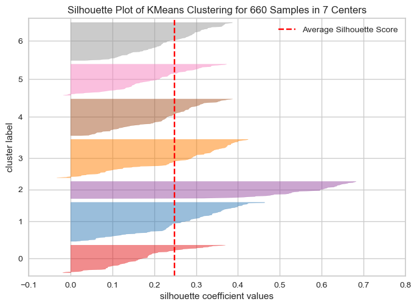

```python
# finding optimal no. of clusters with silhouette coefficients
visualizer = SilhouetteVisualizer(KMeans(7, random_state=1))  ## Complete the code to visualize the silhouette scores for certain number of clusters
visualizer.fit(k_means_df)
visualizer.show()
```

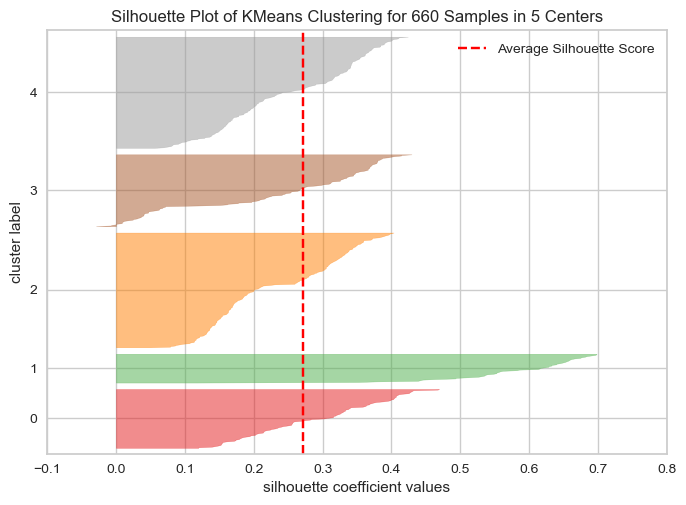

```python
# finding optimal no. of clusters with silhouette coefficients
visualizer = SilhouetteVisualizer(KMeans(5, random_state=1))  ## Complete the code to visualize the silhouette scores for certain number of clusters
visualizer.fit(k_means_df)
visualizer.show()
```

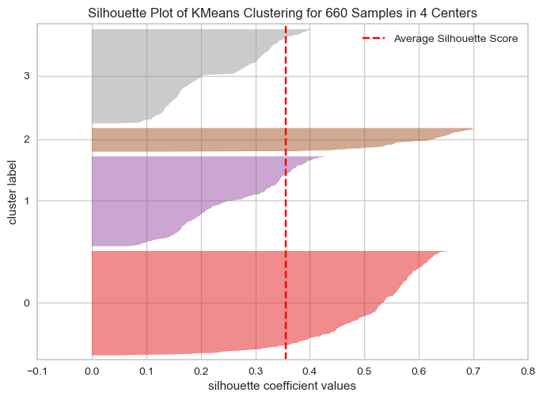

```python
# finding optimal no. of clusters with silhouette coefficients
visualizer = SilhouetteVisualizer(KMeans(4, random_state=1))  ## Complete the code to visualize the silhouette scores for certain number of clusters
visualizer.fit(k_means_df)
visualizer.show()
```

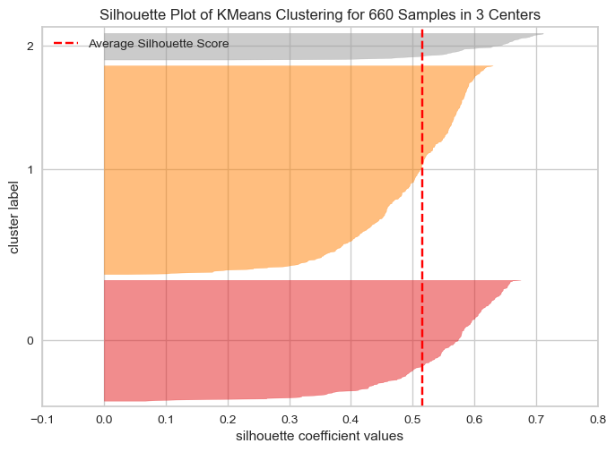

```python
# finding optimal no. of clusters with silhouette coefficients
visualizer = SilhouetteVisualizer(KMeans(3, random_state=1))  ## Complete the code to visualize the silhouette scores for certain number of clusters
visualizer.fit(k_means_df)
visualizer.show()
```

#### OBSERVATIONS

- We see from the above silhuette visualizer scores that, as we reduce teh size of K there are lesser negatives in the graph.
- K = 3 and K =4 does not have any negatives and are the best options to chose the best number of clusters.
- Based on the Elbow and Silhoutte evaludations, choosing K = 3

### Creating Final Model - KMeans

```python
%%time
kmeans = KMeans(n_clusters=3, random_state=1)  ## Complete the code to choose the number of clusters
kmeans.fit(k_means_df)
```

```
CPU times: user 274 ms, sys: 1.68 s, total: 1.96 s
Wall time: 180 ms
```

```
KMeans(n_clusters=3, random_state=1)
```

```python
# creating a copy of the original data
customer_data_copy3 = customer_data_copy2.copy()

# adding kmeans cluster labels to the original and scaled dataframes
k_means_df["K_means_segments"] = kmeans.labels_
customer_data_copy3["K_means_segments"] = kmeans.labels_
```

```python
customer_data_copy3.head()
```

|  | Avg_Credit_Limit | Total_Credit_Cards | Total_visits_bank | Total_visits_online | Total_calls_made | K_means_segments |
| --- | --- | --- | --- | --- | --- | --- |
| 0 | 100000 | 2 | 1 | 1 | 0 | 1 |
| 1 | 50000 | 3 | 0 | 10 | 9 | 0 |
| 2 | 50000 | 7 | 1 | 3 | 4 | 1 |
| 3 | 30000 | 5 | 1 | 1 | 4 | 1 |
| 4 | 100000 | 6 | 0 | 12 | 3 | 2 |

```python
k_means_df.head()
```

|  | Avg_Credit_Limit | Total_Credit_Cards | Total_visits_bank | Total_visits_online | Total_calls_made | K_means_segments |
| --- | --- | --- | --- | --- | --- | --- |
| 0 | 1.740187 | -1.249225 | -0.860451 | -0.547490 | -1.251537 | 1 |
| 1 | 0.410293 | -0.787585 | -1.473731 | 2.520519 | 1.891859 | 0 |
| 2 | 0.410293 | 1.058973 | -0.860451 | 0.134290 | 0.145528 | 1 |
| 3 | -0.121665 | 0.135694 | -0.860451 | -0.547490 | 0.145528 | 1 |
| 4 | 1.740187 | 0.597334 | -1.473731 | 3.202298 | -0.203739 | 2 |

#### OBSERVATIONS

- We have divided the data into 3 clusters [0, 1 & 2] and now can see the new column **K_means_segments** added to the dataset **customer_data_copy3** with values 0,1,2.
- When we look into k_means_df, we can see that the each customer data has in a cluster has been weighted.
- More details on cluster profiling to be added in the profiling section later.

## Hierarchical Clustering

#### Computing Cophenetic Correlation

```python
# Taking a copy of the previously scaled data

hc_df = subset_scaled_df.copy()
```

```python
# list of distance metrics
distance_metrics = ['euclidean','chebyshev','mahalanobis','cityblock'] ## Complete the code to add distance metrics

# list of linkage methods
linkage_methods = ['single', 'complete', 'average', 'weighted'] ## Complete the code to add linkages

high_cophenet_corr = 0
high_dm_lm = [0, 0]

for dm in distance_metrics:
    for lm in linkage_methods:
        Z = linkage(hc_df, metric=dm, method=lm)
        c, coph_dists = cophenet(Z, pdist(hc_df))
        print(
            "Cophenetic correlation for {} distance and {} linkage is {}.".format(
                dm.capitalize(), lm, c
            )
        )
        if high_cophenet_corr < c:
            high_cophenet_corr = c
            high_dm_lm[0] = dm
            high_dm_lm[1] = lm
```

```
Cophenetic correlation for Euclidean distance and single linkage is 0.7391220243806552.
Cophenetic correlation for Euclidean distance and complete linkage is 0.8599730607972423.
Cophenetic correlation for Euclidean distance and average linkage is 0.8977080867389372.
Cophenetic correlation for Euclidean distance and weighted linkage is 0.8861746814895477.
Cophenetic correlation for Chebyshev distance and single linkage is 0.7382354769296767.
Cophenetic correlation for Chebyshev distance and complete linkage is 0.8533474836336782.
Cophenetic correlation for Chebyshev distance and average linkage is 0.8974159511838106.
Cophenetic correlation for Chebyshev distance and weighted linkage is 0.8913624010768603.
Cophenetic correlation for Mahalanobis distance and single linkage is 0.7058064784553606.
Cophenetic correlation for Mahalanobis distance and complete linkage is 0.5422791209801746.
Cophenetic correlation for Mahalanobis distance and average linkage is 0.8326994115042136.
Cophenetic correlation for Mahalanobis distance and weighted linkage is 0.7805990615142516.
Cophenetic correlation for Cityblock distance and single linkage is 0.7252379350252723.
Cophenetic correlation for Cityblock distance and complete linkage is 0.8731477899179829.
Cophenetic correlation for Cityblock distance and average linkage is 0.896329431104133.
Cophenetic correlation for Cityblock distance and weighted linkage is 0.8825520731498188.
```

```python
# printing the combination of distance metric and linkage method with the highest cophenetic correlation
print(
    "Highest cophenetic correlation is {}, which is obtained with {} distance and {} linkage.".format(
        high_cophenet_corr, high_dm_lm[0].capitalize(), high_dm_lm[1]
    )
)
```

```
Highest cophenetic correlation is 0.8977080867389372, which is obtained with Euclidean distance and average linkage.
```

#### OBSERVATION

- We got the high cophenetic correaction of 0.8977 with Euclidean distance and avg linkage.

#### Let's explore different linkage methods with Euclidean distance only.

```python
# list of linkage methods
linkage_methods = ['single', 'complete', 'average','median','ward', 'weighted'] ## Complete the code to add linkages

high_cophenet_corr = 0
high_dm_lm = [0, 0]

for lm in linkage_methods:
    Z = linkage(hc_df, metric="euclidean", method=lm)
    c, coph_dists = cophenet(Z, pdist(hc_df))
    print("Cophenetic correlation for {} linkage is {}.".format(lm, c))
    if high_cophenet_corr < c:
        high_cophenet_corr = c
        high_dm_lm[0] = "euclidean"
        high_dm_lm[1] = lm
```

```
Cophenetic correlation for single linkage is 0.7391220243806552.
Cophenetic correlation for complete linkage is 0.8599730607972423.
Cophenetic correlation for average linkage is 0.8977080867389372.
Cophenetic correlation for median linkage is 0.8893799537016724.
Cophenetic correlation for ward linkage is 0.7415156284827493.
Cophenetic correlation for weighted linkage is 0.8861746814895477.
```

```python
# printing the combination of distance metric and linkage method with the highest cophenetic correlation
print()
print(
    "Highest cophenetic correlation is {}, which is obtained with {} linkage.".format(
        high_cophenet_corr, high_dm_lm[1]
    )
)
```

```
Highest cophenetic correlation is 0.8977080867389372, which is obtained with average linkage.
```

### Checking Dendrograms

#### We see that the cophenetic correlation is maximum with Euclidean distance and average linkage.

#### Let's view the dendrograms for the different linkage methods.

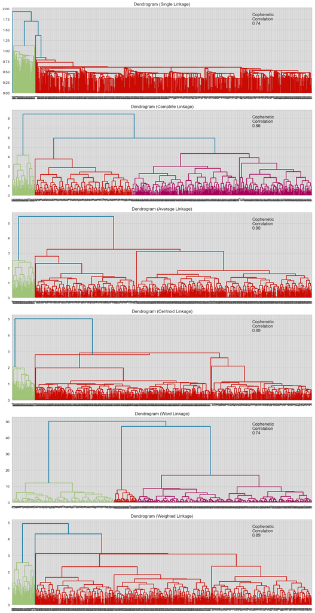

```python
# list of linkage methods
linkage_methods = ["single", "complete", "average", "centroid", "ward", "weighted"] ## Complete the code to add linkages

# lists to save results of cophenetic correlation calculation
compare_cols = ["Linkage", "Cophenetic Coefficient"]
compare = []

# to create a subplot image
fig, axs = plt.subplots(len(linkage_methods), 1, figsize=(15, 30))

# We will enumerate through the list of linkage methods above
# For each linkage method, we will plot the dendrogram and calculate the cophenetic correlation
for i, method in enumerate(linkage_methods):
    Z = linkage(hc_df, metric="euclidean", method=method)

    dendrogram(Z, ax=axs[i])
    axs[i].set_title(f"Dendrogram ({method.capitalize()} Linkage)")

    coph_corr, coph_dist = cophenet(Z, pdist(hc_df))
    axs[i].annotate(
        f"Cophenetic\nCorrelation\n{coph_corr:0.2f}",
        (0.80, 0.80),
        xycoords="axes fraction",
    )

    compare.append([method, coph_corr])
```

#### Dendrogram with average linkage shows distinct and separate cluster tree.

```python
# create and print a dataframe to compare cophenetic correlations for different linkage methods
df_cc = pd.DataFrame(compare, columns=compare_cols)
df_cc = df_cc.sort_values(by="Cophenetic Coefficient")
df_cc
```

|  | Linkage | Cophenetic Coefficient |
| --- | --- | --- |
| 0 | single | 0.739122 |
| 4 | ward | 0.741516 |
| 1 | complete | 0.859973 |
| 5 | weighted | 0.886175 |
| 3 | centroid | 0.893939 |
| 2 | average | 0.897708 |

- From the dendogram linkage we can see that the average adn centroid has the best cophenetic coeff followed by weighted and complete.

```python
sil_score_hc = []
cluster_list = range(2, 10)
for n_clusters in cluster_list:
    clusterer = AgglomerativeClustering(n_clusters=n_clusters, affinity="euclidean", linkage="average")
    preds_hc = clusterer.fit_predict((subset_scaled_df))
    score_hc = silhouette_score(hc_df, preds_hc)
    sil_score_hc.append(score_hc)
    print("For n_clusters = {}, the silhouette score is {})".format(n_clusters, score_hc))
```

```
For n_clusters = 2, the silhouette score is 0.5703183487341072)
For n_clusters = 3, the silhouette score is 0.5159224326511334)
For n_clusters = 4, the silhouette score is 0.4749514359581223)
For n_clusters = 5, the silhouette score is 0.4403975302480271)
For n_clusters = 6, the silhouette score is 0.4153547954833329)
For n_clusters = 7, the silhouette score is 0.41837756746739024)
For n_clusters = 8, the silhouette score is 0.3430671035830017)
For n_clusters = 9, the silhouette score is 0.34154869328928283)
```

### Creating Final Model - Hierarchical Clustering

```python
HCmodel = AgglomerativeClustering(n_clusters=3, affinity="euclidean", linkage="ward")  ## Complete the code to define the hierarchical clustering model
HCmodel.fit(hc_df)
```

```
AgglomerativeClustering(affinity='euclidean', n_clusters=3)
```

```python
# creating a copy of the original data
customer_data_copy4 = customer_data_copy3.copy()

# adding hierarchical cluster labels to the original and scaled dataframes
hc_df["HC_segments"] = HCmodel.labels_
customer_data_copy4["HC_segments"] = HCmodel.labels_
```

```python
hc_df.head()
```

|  | Avg_Credit_Limit | Total_Credit_Cards | Total_visits_bank | Total_visits_online | Total_calls_made | HC_segments |
| --- | --- | --- | --- | --- | --- | --- |
| 0 | 1.740187 | -1.249225 | -0.860451 | -0.547490 | -1.251537 | 0 |
| 1 | 0.410293 | -0.787585 | -1.473731 | 2.520519 | 1.891859 | 1 |
| 2 | 0.410293 | 1.058973 | -0.860451 | 0.134290 | 0.145528 | 0 |
| 3 | -0.121665 | 0.135694 | -0.860451 | -0.547490 | 0.145528 | 0 |
| 4 | 1.740187 | 0.597334 | -1.473731 | 3.202298 | -0.203739 | 2 |

```python
customer_data_copy4.head()
```

|  | Avg_Credit_Limit | Total_Credit_Cards | Total_visits_bank | Total_visits_online | Total_calls_made | K_means_segments | HC_segments |
| --- | --- | --- | --- | --- | --- | --- | --- |
| 0 | 100000 | 2 | 1 | 1 | 0 | 1 | 0 |
| 1 | 50000 | 3 | 0 | 10 | 9 | 0 | 1 |
| 2 | 50000 | 7 | 1 | 3 | 4 | 1 | 0 |
| 3 | 30000 | 5 | 1 | 1 | 4 | 1 | 0 |
| 4 | 100000 | 6 | 0 | 12 | 3 | 2 | 2 |

```python
subset_scaled_df["HC_Clusters"] = HCmodel.labels_
customer_data_copy5 = customer_data_copy4.copy()
customer_data_copy5["HC_Clusters"] = HCmodel.labels_
```

```python
customer_data_copy5.head()
```

|  | Avg_Credit_Limit | Total_Credit_Cards | Total_visits_bank | Total_visits_online | Total_calls_made | K_means_segments | HC_segments | HC_Clusters |
| --- | --- | --- | --- | --- | --- | --- | --- | --- |
| 0 | 100000 | 2 | 1 | 1 | 0 | 1 | 0 | 0 |
| 1 | 50000 | 3 | 0 | 10 | 9 | 0 | 1 | 1 |
| 2 | 50000 | 7 | 1 | 3 | 4 | 1 | 0 | 0 |
| 3 | 30000 | 5 | 1 | 1 | 4 | 1 | 0 | 0 |
| 4 | 100000 | 6 | 0 | 12 | 3 | 2 | 2 | 2 |

#### Observations

- We have also done cluster profiling with hiarchical clustering with 3 clusters.
- Average linkage is with the best cophenetic coeff.

## Cluster Profiling and Comparison

#### Cluster Profiling: K-means Clustering

```python
km_cluster_profile = customer_data_copy5.groupby("K_means_segments").mean()  ## Complete the code to groupby the cluster labels
```

```python
km_cluster_profile["count_in_each_segment"] = (
    customer_data_copy5.groupby("K_means_segments")["Avg_Credit_Limit"].count().values  ## Complete the code to groupby the cluster labels
)
```

```python
km_cluster_profile
```

| K_means_segments | Avg_Credit_Limit | Total_Credit_Cards | Total_visits_bank | Total_visits_online | Total_calls_made | HC_segments | HC_Clusters | count_in_each_segment |
| --- | --- | --- | --- | --- | --- | --- | --- | --- |
| 0 | 12174.107143 | 2.410714 | 0.933036 | 3.553571 | 6.870536 | 1.000000 | 1.000000 | 224 |
| 1 | 33782.383420 | 5.515544 | 3.489637 | 0.981865 | 2.000000 | 0.002591 | 0.002591 | 386 |
| 2 | 141040.000000 | 8.740000 | 0.600000 | 10.900000 | 1.080000 | 2.000000 | 2.000000 | 50 |

```python
all_col = km_cluster_profile.columns
```

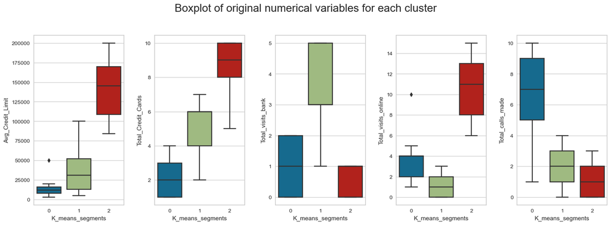

```python
fig, axes = plt.subplots(1, 5, figsize=(16, 6))
fig.suptitle("Boxplot of original numerical variables for each cluster", fontsize=20)
counter = 0
for ii in range(5):
    sns.boxplot(ax=axes[ii], y=customer_data_copy5[all_col[counter]], x=customer_data_copy5["K_means_segments"])
    counter = counter + 1

fig.tight_layout(pad=2.0)
```

#### Cluster Profiling: Hierarchical Clustering

```python
hc_cluster_profile = customer_data_copy5.groupby("HC_segments").mean()
```

```python
hc_cluster_profile["count_in_each_segment"] = (
    customer_data_copy5.groupby("HC_segments")["Avg_Credit_Limit"].count().values
)
```

```python
hc_cluster_profile
```

| HC_segments | Avg_Credit_Limit | Total_Credit_Cards | Total_visits_bank | Total_visits_online | Total_calls_made | K_means_segments | HC_Clusters | count_in_each_segment |
| --- | --- | --- | --- | --- | --- | --- | --- | --- |
| 0 | 33851.948052 | 5.516883 | 3.493506 | 0.979221 | 1.994805 | 1.000000 | 0.0 | 385 |
| 1 | 12151.111111 | 2.422222 | 0.937778 | 3.546667 | 6.857778 | 0.004444 | 1.0 | 225 |
| 2 | 141040.000000 | 8.740000 | 0.600000 | 10.900000 | 1.080000 | 2.000000 | 2.0 | 50 |

```python
# Further details on cluster profiling on HC:

hcall_col = hc_cluster_profile.columns
```

```python
for cl in customer_data_copy5["HC_Clusters"].unique():
    print("In cluster {}, the following credif card counts are present ".format(cl))
    print(customer_data_copy5[customer_data_copy5["HC_Clusters"] == cl]["Total_Credit_Cards"].unique())
    print()
```

```
In cluster 0, the following credif card counts are present
[2 7 5 4 6]

In cluster 1, the following credif card counts are present
[3 2 4 1 5]

In cluster 2, the following credif card counts are present
[ 6  5  9  8 10  7]
```

```python
for cl in customer_data_copy5["HC_Clusters"].unique():
    print("In cluster {}, the following Bank Visits are present ".format(cl))
    print(customer_data_copy5[customer_data_copy5["HC_Clusters"] == cl]["Total_visits_bank"].unique())
    print()
```

```
In cluster 0, the following Bank Visits are present
[1 2 5 3 4]

In cluster 1, the following Bank Visits are present
[0 2 1]

In cluster 2, the following Bank Visits are present
[0 1]
```

```python
for cl in customer_data_copy5["HC_Clusters"].unique():
    print("In cluster {}, the following Total_visits_online are present ".format(cl))
    print(customer_data_copy5[customer_data_copy5["HC_Clusters"] == cl]["Total_visits_online"].unique())
    print()
```

```
In cluster 0, the following Total_visits_online are present
[1 3 0 2]

In cluster 1, the following Total_visits_online are present
[10  1  2  5  4  3]

In cluster 2, the following Total_visits_online are present
[12 11 14  7 10 13 15  6  8  9]
```

```python
for cl in customer_data_copy5["HC_Clusters"].unique():
    print("In cluster {}, the following Total_visits_online are present ".format(cl))
    print(customer_data_copy5[customer_data_copy5["HC_Clusters"] == cl]["Total_calls_made"].unique())
    print()
```

```
In cluster 0, the following Total_visits_online are present
[0 4 2 3 1]

In cluster 1, the following Total_visits_online are present
[ 9  8  1  2  7  5  6  4 10]

In cluster 2, the following Total_visits_online are present
[3 2 1 0]
```

#### OBSERVATIONS

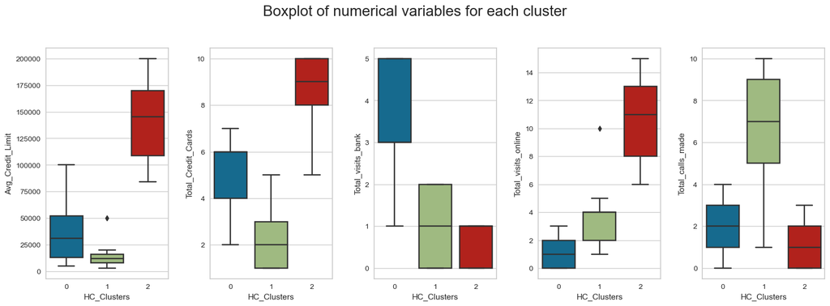

```python
fig, axes = plt.subplots(1, 5,  figsize=(16, 6))
fig.suptitle('Boxplot of numerical variables for each cluster', fontsize=20)
counter = 0
for ii in range(5):
    sns.boxplot(ax=axes[ii],y=customer_data_copy5[hcall_col[counter]],x=customer_data_copy5['HC_Clusters'])
    counter = counter+1

fig.tight_layout(pad=2.0)
```

#### Observations

- From the box plot we can see that
- Cluster 0:
  - Avg Credit: limit us below 50K
  - Total CC: between 4 to 6
  - Total bank visits: between 3-5
  - Total online vists: are betweeen 0 to 2
  - Total calls made: 1 to 3
- Cluster 1:
  - Avg Credit: limit us below 20K
  - Total CC: between 1 to 3
  - Total bank visits: between 0-2
  - Total online vists: are betweeen 2 to 4
  - Total calls made: 5 to 9
- Cluster 2:
  - Avg Credit: limit in in range 100K - 175K
  - Total CC: between 8 to 10
  - Total bank visits: between 0-1
  - Total online vists: are betweeen 8 to 13
  - Total calls made: 0 to 2

## K-means vs Hierarchical Clustering

Here we can compare several things, like:

- Which clustering technique took less time for execution?
- Which clustering technique gave you more distinct clusters, or are they the same?
- How many observations are there in the similar clusters of both algorithms?
- How many clusters are obtained as the appropriate number of clusters from both algorithms?

You can also mention any differences or similarities you obtained in the cluster profiles from both the clustering techniques.

```python
km_cluster_profile.style.highlight_max(color="lightgreen", axis=0)
```

| K_means_segments | Avg_Credit_Limit | Total_Credit_Cards | Total_visits_bank | Total_visits_online | Total_calls_made | HC_segments | HC_Clusters | count_in_each_segment |
| --- | --- | --- | --- | --- | --- | --- | --- | --- |
| 0 | 12174.107143 | 2.410714 | 0.933036 | 3.553571 | 6.870536 | 1.000000 | 1.000000 | 224 |
| 1 | 33782.383420 | 5.515544 | 3.489637 | 0.981865 | 2.000000 | 0.002591 | 0.002591 | 386 |
| 2 | 141040.000000 | 8.740000 | 0.600000 | 10.900000 | 1.080000 | 2.000000 | 2.000000 | 50 |

```python
hc_cluster_profile.style.highlight_max(color="lightgreen", axis=0)
```

| HC_segments | Avg_Credit_Limit | Total_Credit_Cards | Total_visits_bank | Total_visits_online | Total_calls_made | K_means_segments | HC_Clusters | count_in_each_segment |
| --- | --- | --- | --- | --- | --- | --- | --- | --- |
| 0 | 33851.948052 | 5.516883 | 3.493506 | 0.979221 | 1.994805 | 1.000000 | 0.000000 | 385 |
| 1 | 12151.111111 | 2.422222 | 0.937778 | 3.546667 | 6.857778 | 0.004444 | 1.000000 | 225 |
| 2 | 141040.000000 | 8.740000 | 0.600000 | 10.900000 | 1.080000 | 2.000000 | 2.000000 | 50 |

#### OBSERVATIONS (KMeans)

- KM-Cluster 0:
  - Avg_Credit_Limit: Customers in this segment have an average credit limit of approximately 12,174.
  - Total_Credit_Cards: On average, they have around 2.41 total credit cards.
  - Total_visits_bank: These customers make an average of approximately 0.93 visits to the bank.
  - Total_visits_online: They tend to make around 3.55 online visits.
  - Total_calls_made: On average, they make about 6.87 customer service calls.
  - HC_segments: The hierarchical clustering segment for this cluster is 1.
  - HC_Clusters: The hierarchical clustering cluster label is 1.
  - count_in_each_segment: There are 224 customers in this segment.
- KM-Cluster 1:
  - Avg_Credit_Limit: Customers in this segment have a significantly higher average credit limit of approximately 33,782.
  - Total_Credit_Cards: On average, they have about 5.52 total credit cards, indicating higher credit card ownership.
  - Total_visits_bank: These customers make an average of approximately 3.49 visits to the bank, suggesting a preference for in-person banking.
  - Total_visits_online: They make fewer online visits, with an average of about 0.98.
  - Total_calls_made: On average, they make about 2 customer service calls.
  - HC_segments: The hierarchical clustering segment for this cluster is 0.
  - HC_Clusters: The hierarchical clustering cluster label is 0.
  - count_in_each_segment: There are 386 customers in this segment.
- KM-Cluster 2:
  - Avg_Credit_Limit: Customers in this segment have a very high average credit limit of 141,040.
  - Total_Credit_Cards: On average, they have a substantial number of credit cards, approximately 8.74.
  - Total_visits_bank: These customers make very few visits to the bank, with an average of only 0.6.
  - Total_visits_online: They heavily prefer online interactions, making an average of 10.9 online visits.
  - Total_calls_made: On average, they make around 1.08 customer service calls.
  - HC_segments: The hierarchical clustering segment for this cluster is 2.
  - HC_Clusters: The hierarchical clustering cluster label is 2.
  - count_in_each_segment: There are 50 customers in this segment.

#### OBSERVATIONS (Hierarchical Clustering)

- HC Cluster 0:
  - Avg_Credit_Limit: Customers in this segment have an average credit limit of approximately 33,852.
  - Total_Credit_Cards: On average, they have around 5.52 total credit cards, indicating a moderate number of credit cards.
  - Total_visits_bank: These customers make an average of approximately 3.49 visits to the bank, suggesting a preference for in-person banking.
  - Total_visits_online: They make fewer online visits, with an average of about 0.98 online visits.
  - Total_calls_made: On average, they make approximately 1.99 customer service calls.
  - K_means_segments: This segment corresponds to K-means cluster 1.
  - HC_Clusters: The hierarchical clustering assigned this segment to cluster 0.
  - count_in_each_segment: There are 385 customers in this segment.
- HC Cluster 1:
  - Avg_Credit_Limit: Customers in this segment have a lower average credit limit of approximately 12,151.
  - Total_Credit_Cards: On average, they have about 2.42 total credit cards, indicating lower credit card ownership.
  - Total_visits_bank: These customers make an average of approximately 0.94 visits to the bank, suggesting a lower preference for in-person banking.
  - Total_visits_online: They tend to make around 3.55 online visits, indicating a higher preference for online interactions.
  - Total_calls_made: On average, they make approximately 6.86 customer service calls.
  - K_means_segments: This segment corresponds to K-means cluster 0.
  - HC_Clusters: The hierarchical clustering assigned this segment to cluster 1.
  - count_in_each_segment: There are 225 customers in this segment.
- HC Cluster 2:
  - Avg_Credit_Limit: Customers in this segment have an exceptionally high average credit limit of 141,040.
  - Total_Credit_Cards: On average, they have a substantial number of credit cards, approximately 8.74.
  - Total_visits_bank: These customers make very few visits to the bank, with an average of only 0.6.
  - Total_visits_online: They heavily prefer online interactions, making an average of 10.9 online visits.
  - Total_calls_made: On average, they make around 1.08 customer service calls.
  - K_means_segments: This segment corresponds to K-means cluster 2.
  - HC_Clusters: The hierarchical clustering assigned this segment to cluster 2.
  - count_in_each_segment: There are 50 customers in this segment.

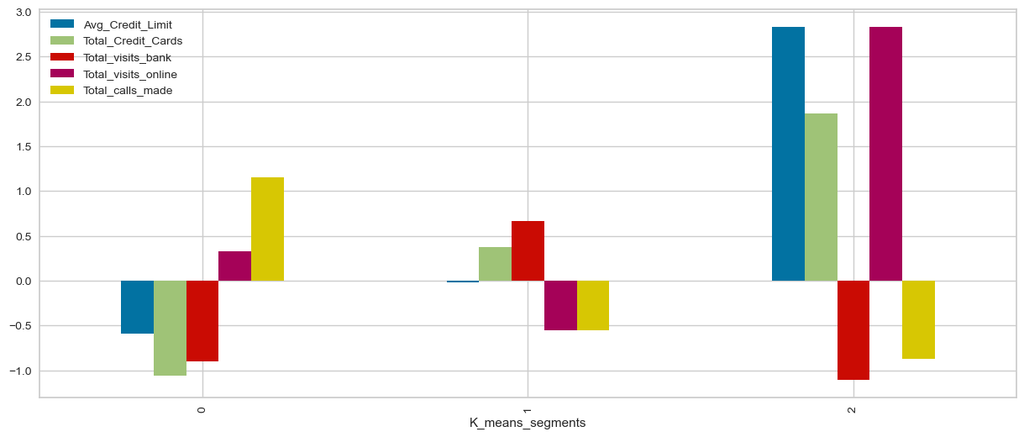

```python
k_means_df.groupby("K_means_segments").mean().plot.bar(figsize=(15, 6))
```

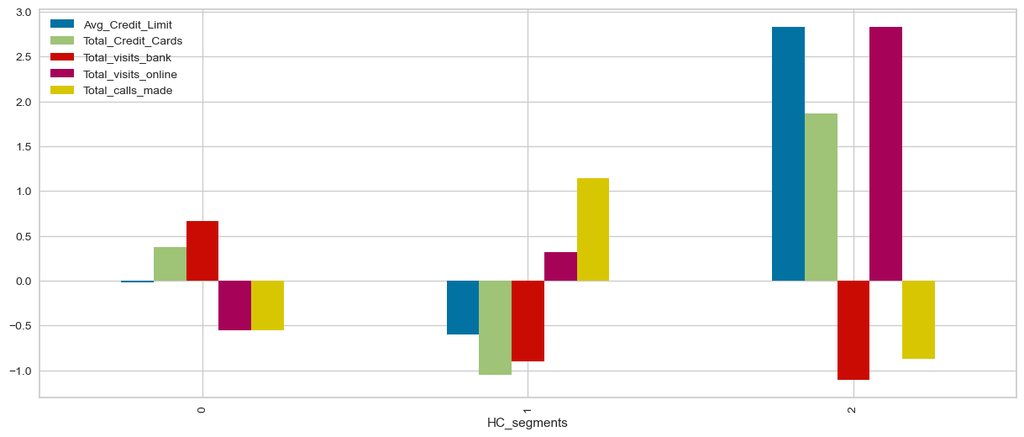

```python
hc_df.groupby("HC_segments").mean().plot.bar(figsize=(15, 6))
```

```python
k_means_df.loc[k_means_df["K_means_segments"] == 1, "K_means_segments"] = 3
k_means_df.loc[k_means_df["K_means_segments"] == 2, "K_means_segments"] = 1
k_means_df.loc[k_means_df["K_means_segments"] == 3, "K_means_segments"] = 2
customer_data_copy5["K_means_segments"] = k_means_df["K_means_segments"]

km_cluster_profile = customer_data_copy5.groupby("K_means_segments").mean()
km_cluster_profile["count_in_each_segment"] = (
    customer_data_copy5.groupby("K_means_segments")["Avg_Credit_Limit"].count().values
)
```

```python
km_cluster_profile.style.highlight_max(color="lightgreen", axis=0)
```

| K_means_segments | Avg_Credit_Limit | Total_Credit_Cards | Total_visits_bank | Total_visits_online | Total_calls_made | HC_segments | HC_Clusters | count_in_each_segment |
| --- | --- | --- | --- | --- | --- | --- | --- | --- |
| 0 | 12174.107143 | 2.410714 | 0.933036 | 3.553571 | 6.870536 | 1.000000 | 1.000000 | 224 |
| 1 | 141040.000000 | 8.740000 | 0.600000 | 10.900000 | 1.080000 | 2.000000 | 2.000000 | 50 |
| 2 | 33782.383420 | 5.515544 | 3.489637 | 0.981865 | 2.000000 | 0.002591 | 0.002591 | 386 |

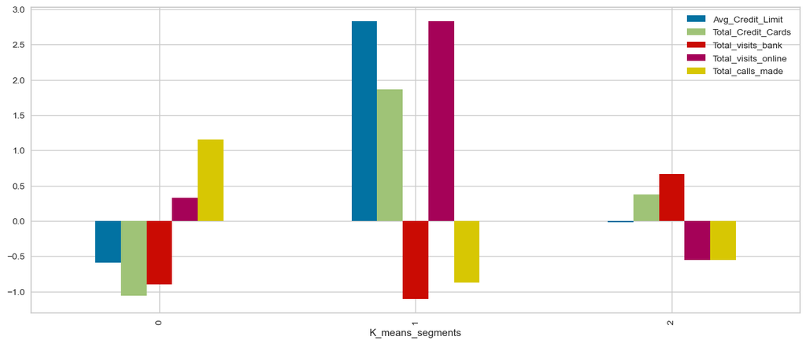

```python
k_means_df.groupby("K_means_segments").mean().plot.bar(figsize=(15, 6))
```

#### Let's create some plots on the original data to understand the customer distribution among the clusters.

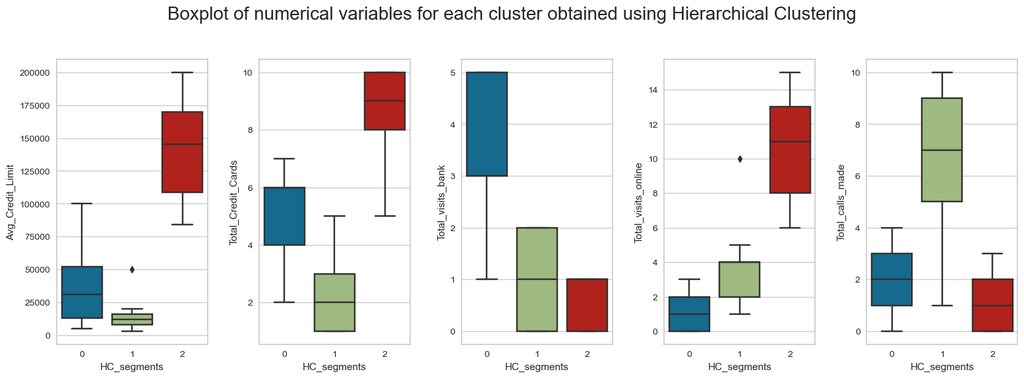

```python
fig, axes = plt.subplots(1, 5, figsize=(16, 6))
fig.suptitle(
    "Boxplot of numerical variables for each cluster obtained using Hierarchical Clustering",
    fontsize=20,
)

counter = 0

for ii in range(5):
    sns.boxplot(ax=axes[ii], y=customer_data_copy5[customer_data_copy5.columns[counter]], x=hc_df["HC_segments"])
    counter = counter + 1

fig.tight_layout(pad=2.0)
```

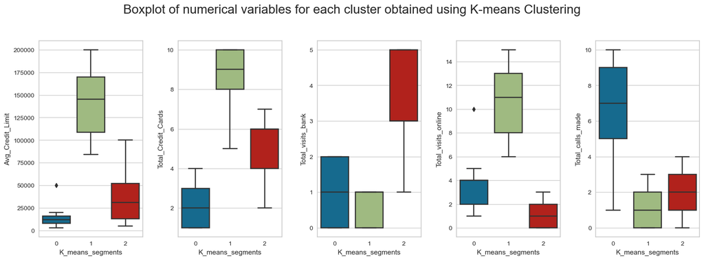

```python
fig, axes = plt.subplots(1, 5, figsize=(16, 6))
fig.suptitle(
    "Boxplot of numerical variables for each cluster obtained using K-means Clustering",
    fontsize=20,
)

counter = 0

for ii in range(5):
    sns.boxplot(
        ax=axes[ii], y=customer_data_copy5[customer_data_copy5.columns[counter]], x=k_means_df["K_means_segments"]
    )
    counter = counter + 1

fig.tight_layout(pad=2.0)
```

###### Adding cluster comparison for folks with 'Avg_Credit_Limit' and 'Total_Credit_Cards' to see their cluster distribution

```python
pd.crosstab(customer_data_copy5.HC_Clusters, customer_data_copy5.Avg_Credit_Limit).style.highlight_max(color="lightgreen", axis=0)
```

| Avg_Credit_Limit HC_Clusters | 3000 | 5000 | 6000 | 7000 | 8000 | 9000 | 10000 | 11000 | 12000 | 13000 | 14000 | 15000 | 16000 | 17000 | 18000 | 19000 | 20000 | 25000 | 26000 | 27000 | 28000 | 29000 | 30000 | 31000 | 32000 | 33000 | 34000 | 35000 | 36000 | … |
| --- | --- | --- | --- | --- | --- | --- | --- | --- | --- | --- | --- | --- | --- | --- | --- | --- | --- | --- | --- | --- | --- | --- | --- | --- | --- | --- | --- | --- | --- | --- |
| 0 | 0 | 8 | 14 | 10 | 15 | 10 | 12 | 9 | 10 | 10 | 9 | 6 | 9 | 10 | 14 | 13 | 7 | 1 | 5 | 2 | 3 | 5 | 6 | 5 | 2 | 4 | 6 | 2 | 11 | … |
| 1 | 1 | 13 | 17 | 14 | 20 | 18 | 14 | 15 | 8 | 18 | 14 | 11 | 13 | 13 | 9 | 13 | 13 | 0 | 0 | 0 | 0 | 0 | 0 | 0 | 0 | 0 | 0 | 0 | 0 | … |
| 2 | 0 | 0 | 0 | 0 | 0 | 0 | 0 | 0 | 0 | 0 | 0 | 0 | 0 | 0 | 0 | 0 | 0 | 0 | 0 | 0 | 0 | 0 | 0 | 0 | 0 | 0 | 0 | 0 | 0 | … |

```python
pd.crosstab(customer_data_copy5.HC_Clusters, customer_data_copy5.Total_Credit_Cards).style.highlight_max(color="lightgreen", axis=0)
```

| Total_Credit_Cards HC_Clusters | 1 | 2 | 3 | 4 | 5 | 6 | 7 | 8 | 9 | 10 |
| --- | --- | --- | --- | --- | --- | --- | --- | --- | --- | --- |
| 0 | 0 | 1 | 0 | 102 | 72 | 116 | 94 | 0 | 0 | 0 |
| 1 | 59 | 63 | 53 | 49 | 1 | 0 | 0 | 0 | 0 | 0 |
| 2 | 0 | 0 | 0 | 0 | 1 | 1 | 7 | 11 | 11 | 19 |

```python
customer_data_copy5.head()
```

|  | Avg_Credit_Limit | Total_Credit_Cards | Total_visits_bank | Total_visits_online | Total_calls_made | K_means_segments | HC_segments | HC_Clusters |
| --- | --- | --- | --- | --- | --- | --- | --- | --- |
| 0 | 100000 | 2 | 1 | 1 | 0 | 2 | 0 | 0 |
| 1 | 50000 | 3 | 0 | 10 | 9 | 0 | 1 | 1 |
| 2 | 50000 | 7 | 1 | 3 | 4 | 2 | 0 | 0 |
| 3 | 30000 | 5 | 1 | 1 | 4 | 2 | 0 | 0 |
| 4 | 100000 | 6 | 0 | 12 | 3 | 1 | 2 | 2 |

#### Using KMeans clustering to give insights and recommendations to the business.

## Actionable Insights

#### Cluster 0

- Customers in this segment have low credit card usage below 20K
- Number of CC with customers in this segment are 1 to 3
- These customers make some visits to the bank in person
- These customers make less online visits 2 - 4
- These cusomers tend to call more to the bank in a year (more than 5)
- This cluster has 224 customers

#### Cluster 1

- Customers in this segment have highest credit card usage above 100K
- Number of CC with customers in this segment is above 8, being max amongst all the clusters.
- These customers make least visits to the bank in person
- These customers make the most online visits
- These cusomers tend to call least to the bank in a year
- This cluster has 50 customers

Hence, Cluster 1 includes customers with very high average credit limits and a significant number of credit cards. They prefer online interactions over visiting the bank and have the lowest number of calls made. These customers might be high-income individuals or businesses.

#### Cluster 2

And finally, Cluster 2 consists of customers with moderate credit limits, a moderate number of credit cards, and a strong preference for visiting the bank. They have the highest number of visits to the bank but the lowest online visits. The number of calls made is also moderate.

## Business Recommendations

#### Cluster 0:

- Consider offering online banking services and tools to help these customers manage their accounts more efficiently, potentially reducing the need for frequent phone calls.
- Provide targeted promotions or credit card offers to encourage them to increase their credit card usage.

#### Cluster 1:

- These are customers with high values and bigger cc limits and financial products.
- Focus on enhancing online banking services, as these customers prefer online interactions. Invest in a user-friendly online platform and offer exclusive benefits to retain their loyalty.
- Offer premium credit card options and high-value financial products to cater to their high income and credit capacity.

#### Cluster 2:

- Continue to emphasize in-person banking experiences and provide personalized assistance at bank branches.
- Explore strategies to transition some of these customers to online banking by showcasing the convenience and benefits of online services.